# KorTobis project report

Kristian Ege Nielsen

# 1 Preliminary talk

1 Preliminary info on the data and project structure This document is ment as a runthrough of the data treatment, but by embedding the project R-scripts it both serves as a master document and complete documentation of entire R-project related to the otolith part of the KorTobis project.

The report is written in r-markdown

All relevant project datafiles, functions and scripts are found in the R-studio project folder eff-tobis, as I find this the current best pracsis of organization. This folder is furthermore linked to a version control on github https://github.com/kristianege/eff-tobis, primarily on first hand for my sake, as I’m a bit tired of to many versions of files. You can simply download the project folder in its current state as a zip file from the github repository or do it directly from this link.

If you want to dig into the version control please be my guest, this would make life a lot easier for everybody on the long run, and deminish a lot of repetition.

The most easy way to evaluate and ad changes to pressent report is to open the Project report.Rmd file in R studie and compile to HTML with knitr. The report itself can viewed by oppening the Project report.html file in the project folder in your browser, or if in r-studio just clicking on it.

The newer versions of R-studio comes with packrat integration, however you have to install the packrat package.

You can extract alle the R code in the markdown document with by running:

```r
library (knitr)
purl(“Projectreport.rmd”,output=“Your_R_File_name.R”)
```

# 2 Methods

## 2.1 Otolith preperation, imaging and measurement documentation

The following files contains information on how otolith were worked up.

- *Protocol_otolith_preparation.doc*, documentation on how otoliths were prepared
- *Protocol_otolith_image&measurement.doc*, documentation on imaging and measurements
- *Naming of images.doc*, how images were named

I’ll just briefely note here that for each larvae if possible both otolith were measured. But in some cases one was lost. In each otolith dayli increments were measured in two radii, on in direction of fastest growth and one some other direction, usually the best visible alternative direction, however not in any systematic way.

# 3 Otolith data workup

## 3.1 Larvae otoliths

### 3.1.1 csv data files

- *raw_larvae_otolith_measurements.csv*, the raw larvae otolith data
- *mark_to_delete_r1.csv*, wrongly marked dayli increments to be deleted for radius 1
- *mark_to_delete_r1.csv*, wrongly marked dayli increments to be deleted for radius 2
- *KorTobis_metadata.csv*, Meta data for sampled larvae
- *KorTobis_larvaelgd2_sdl2.csv*, Standard length of treated larvae
- *station_rename.csv*, abbreviated station names mostly for plotting purpouses

I have only included the in the indirectly in this document, since it is rather comprehensive and several pages long. In the following code chuncks the used scripts are sourced. If your want to review the files you should look into the sourced R code.

The following code chunk runs the script *manipulation-1-raw-larvae-otolith-data.R*

### 3.1.2 R code

```r
source("manipulation-1-raw-larvae-otolith-data.R")
```

The script treats the raw larval otolith readings *raw_larvae_otolith_measurements.csv* and produces the following:

- 1. Removes wrongly marked otolith rings, the marks were reviewed in pictures using a Matlab script
- 2. Transforms all distances from pixels to microns
- 3. Recalculates distance between the otolith dayli rings after removal of wrongly red rings
- 4. Ring width are filtered so that they are between 0.5 and 9 microns 5. Ringwidths bigger than 1.8 the following ring are excluded, this in order to sort out areas with no readings.

The resulting output dataframe is called *oto2* also the raw data is maintained in the global environment as *oto_raw* both data frames are used in the next script *manipulation-2-bestage-selection-and-more.R*:

```r
source("manipulation-2-bestage-selection-and-more.R")
```

This script is a bit more comprehensive and draws on several other scipts

1. Removes readings in the outer 10% of the otolith to avoid any edge effect. Resulting data frame *oto_no_edge*
2. Removes otoliths in which the predicted linear relationship between distance to center and the ring width does not pass through an interval of max and min ringwidth at 20 microns. The resulting data frame *oto_inc_fit*
3. A linear model is then run on all each individual otolith radial reading. The model information is added to the data frame so that the data frame *oto_filtered_model* contains all model parameterisations for each red otolith radius.
4. Model information as residuals, cooks distance, fitted values for each ringwidth is found in the data frame *oto_filtered_all*
5. The script then sources three other scripts that are quite complex to explain, but the output is a selection of best ages for each fish. Where best age is selected on basis of highest number of daily increments in estimate, and secondary higher age this is done for both measured radii.
6. Metadata as position etc. is added
7. The two data frames *oto_filtered_all* and *oto_filtered_model* are then synced to include only the otoliths with “best ages”.

The output data frames are:  
* *oto4*, containing all measurements after the above mentioned filtering  
* *oto5*, containing the lm linear model parameters per filtered and selected larvae. These data frames are also available as csv’s *otolith_filtered_all_marks* and *otolith_filtered* in the project folder.

### 3.1.3 Further age-length cleanup

In the data frame d for plotting and some analysis including standard lengths, age and length outliers are removed and and stations are given a abbreveated name. To catagorize larvae as smaller or bigger, measured larvae are divided into larvae with or without secondary growth center in the coloumn growth_center this both for data frames *d*, *oto2*, *oto4*, *oto5*.

```r
#shorter names for the
station_rename<- read.csv("station_rename.csv", header=TRUE, sep=",", na.strings="NA", dec=".")
d <- subset(oto5,measured_radius == 1 & slope > 0 & slope<0.075)
d$year<-factor(d$year)
#short names for stations added
d<-d%>%left_join(.,station_rename,by="KorTobis_sample_id")%>%mutate(st_shortname=paste(as.character(area),st_shortname,sep=""))
d2<-subset(oto4,measured_radius==1)
d$st_shortname<-factor(d$st_shortname)

#These guys have odd lengths
d<-filter(d,!larvae_id%in%c("CY_38_02-05-06_02","CY_25_22-04-06_18","CY_37_01-05-06_18","PK_09_21-04-08_19"))

all08<-d%>%filter(year==2008)
all09<-d%>%filter(year==2009)
all06<-d%>%filter(year==2006)

#pulls out fish with no length measured
d_no_NA<-filter(d,!is.na(sd_lgd))

#For small and larger larvae selection (With or without secondary growth center)
oto_growth_center <- oto_raw %>%
  group_by(pic_id)%>%
  summarize(growth_center=mean(dist_sec_growth_center))%>%
  mutate(growth_center = ifelse(is.na(growth_center),"No_sec_growth_center","Have_sec_growth_center"))


oto2 <- oto2%>%
  left_join(.,oto_growth_center,by="pic_id")


oto4 <- oto4%>%
  left_join(.,oto_growth_center,by="pic_id")

oto5 <- oto5%>%
  left_join(.,oto_growth_center,by="pic_id")

d <- d%>%
  left_join(.,oto_growth_center,by="pic_id")


rm(oto_growth_center)
```

### 3.1.4 Resulting data frames

So after treatment of raw data and finding the linear relation between ring width and distance from center the following data frames are available:

- *oto_raw*, all the larvae and raw data
- *oto2*, treated measurements but before running linear model to find otolith growth, and before selecting according otoliths pr. fish according to “best ages”
- *oto4*, all increment measurements after treatment and filtering, including model information. Only otoliths remaining after best ages selection .
- *oto5*, containing linear model information from the relation between increment width and distance to center of otolith. Only otoliths remaining after best ages selection meta, with worked up metadata for further data exploration, same meta used for length measurements
- *d*, see previous section for details

## 3.2 Fish otolith data workup

### 3.2.1 Csv data files

Csv files for the fish part of the:

- *Farivar_22.04.15.csv*, raw data of fish otolith measurements
- *meta_SK.csv*, meta data from dredge samples, pre winter
- -meta_TBM.csv_, meta data from fishery, post winter
- *map_farivar.csv*, for mapping of stations

### 3.2.2 R code

```r
#Loads otolith readings from juvenile and adult fish. Before and after winter
farivar<-read.csv("Farivar_22.04.15.csv",header=TRUE,sep=',',na.strings=c("NA"))

#meta data from before winter
meta_SK<-read.csv("meta_SK.csv",header=TRUE,sep=',',na.strings=c("NA"),strip.white=TRUE)

#meta data from after winter
meta_TBM<-read.csv("meta_TBM.csv",header=TRUE,sep=',',na.strings=c("NA"))

#Loading costume functions used in script
#These have been used in the previous code
#source("zero_to_na.R")
#source("all_model_info.R")

#This transforms positions from degree decimal minutes to dec degrees
source("deg_decmin_2decdeg.R")

############################################################################
# Measurement workup and cleanup, done equivalently to the larvae otoliths -
############################################################################

farivar<-farivar%>%
      mutate(dist_btw_markers=dist_btw_markers/X20_pix_pr_micron,
             dist_to_center=dist_to_center/X20_pix_pr_micron)%>%
      select(-magnification,-X20_pix_pr_micron)

farivar1 <-  farivar %>%
      arrange(fish_id,mark_no)%>%
      group_by(fish_id)%>%
      mutate(dist_to_center = cumsum(dist_btw_markers),
            dist_to_center = lag(dist_to_center, default = NA),
            dist_btw_markers = zero_to_na(dist_btw_markers)) %>%
      filter(!is.na(dist_btw_markers),!is.na(dist_to_center))%>%  #removes center to 2nd mark dist and last mark with dist = 0
      filter(dist_btw_markers  < 1.8 * lead(dist_btw_markers, default = Inf))%>%
      ungroup()


faulty_measures<-farivar1%>%filter(dist_to_center<15)%>%distinct(fish_id) #these could be be corrected if I had the time

farivar1<-farivar1%>%anti_join(.,faulty_measures,by="fish_id")%>%filter(dist_btw_markers>0.5,dist_btw_markers<10,dist_to_center<140)

rm(faulty_measures)
############################################################################
# Workup of regression info -----------------------------------------------
############################################################################
farivar2 <- all_model_info(farivar1%>%filter(dist_to_center<140),c("fish_id"),"dist_btw_markers","dist_to_center")

#Dredge or Fishery selection

farivar2 <- farivar2%>%
      mutate(fishery_dredge = substr(fish_id,1,1),
                              fishery_dredge = ifelse(fishery_dredge=="T","Fishery","Dredge"))%>% #fishery dredge factor
      left_join(.,farivar%>%select(fish_id,fish_length)%>%distinct(fish_id),by="fish_id") #re-adds the fish lengths




farivar_fish <- farivar2%>%filter(fishery_dredge=="Fishery")%>%
      mutate(year=paste("20",substr(fish_id,4,5),sep=""),
             hatch_year=factor(as.numeric(year)-1),
             meta_id = paste(substr(fish_id,1,11),substring(fish_id,14,14),sep="")) #note that this only works because all stations contains one figure

farivar_dredge <- farivar2%>%filter(fishery_dredge=="Dredge")%>%
      mutate(year=paste("20",substr(fish_id,3,4),sep=""),
             hatch_year=factor(year),
             meta_id = paste(substr(fish_id,1,10),substring(fish_id,13,14),sep="")) #note that this only works because all stations contains two figures


farivar2<-rbind(farivar_fish,farivar_dredge)

rm(farivar_fish,farivar_dredge)


#farivar1 is used next to create regression information for same fish as in farivar2
farivar1<-inner_join(farivar1,select(farivar2,fish_id,fishery_dredge,year,hatch_year,meta_id),by=("fish_id"))

###########################################################################
# Dataset with individual increment model info ----------------------------
###########################################################################
#
# library(broom)
# regression<-farivar1 %>%      #Adds list of all lm objects with fish_id as key
#       group_by(fish_id)%>%
#       do(fit=lm(dist_btw_markers~dist_to_center, data = .))
#
# farivar3<-regression%>%
#       glance(fit)%>%          #produces all statistics related to each increment in the regression
#       mutate(fishery_dredge = substr(fish_id,1,1),
#              fishery_dredge = ifelse(fishery_dredge=="T","Fishery","Dredge"))
#
# farivar_fish <- farivar3%>%
#       filter(fishery_dredge=="Fishery")%>%
#       mutate(year = paste("20",substr(fish_id,4,5),sep=""),
#              hatch_year = factor(as.numeric(year)-1),
#              meta_id = paste(substr(fish_id,1,11),substr(fish_id,14,14),sep=""))%>%
#       select(-year)
#
# farivar_dredge <- farivar3%>%
#       filter(fishery_dredge=="Dredge")%>%
#       mutate(year=paste("20",substr(fish_id,3,4),sep=""),
#              hatch_year=factor(year),
#              meta_id = paste(substr(fish_id,1,10),substr(fish_id,13,14),sep=""))%>%
#       select(-year)
#
# farivar3<-rbind(farivar_fish,farivar_dredge)
# rm(farivar_fish,farivar_dredge)

############################################################################
# Meta data workup --------------------------------------------------------
############################################################################
# The TBM data
meta_TBM<-meta_TBM%>%
      mutate(latPosStartDec = deg_decmin_2decdeg(as.character(latPosStartText)), #converting position format to dec. degrees
             lonPosStartDec = deg_decmin_2decdeg(as.character(lonPosStartText)),
             latPosEndDec   = deg_decmin_2decdeg(as.character(latPosEndText)),
             lonPosEndDec   = deg_decmin_2decdeg(as.character(lonPosEndText)),
             day = substr(as.character(Dato),1,2),
             month = substr(as.character(Dato),4,5),
             year = substr(as.character(Dato),7,10),
             rdate = as.Date(as.character(Dato),format='%d/%m/%Y'),
             meta_id = paste(Navn,Station,sep="-"),
             station=Station
      )%>%
      select(meta_id,latPosStartDec,lonPosStartDec,day,month,year,rdate,station) #I choose start position as st. position and date

#The Dredging
meta_SK<-meta_SK%>%
      mutate(meta_id = paste(paste(paste("SK",substr(as.character(year),3,4),sep=""),as.character(cruise),sep="-"),as.character(station),sep="-"),
             day = substr(as.character(datestart),1,2),
             month = substr(as.character(datestart),4,5),
             year = substr(as.character(datestart),7,10),
             rdate = as.Date(as.character(datestart),format='%d/%m/%Y')
      )%>%
      select(meta_id,latPosStartDec,lonPosStartDec,day,month,year,rdate,station)#I choose start position as st. position and date

meta_farivar<-rbind(meta_TBM,meta_SK)
###########################################################################
# Merging meta ------------------------------------------------------------
###########################################################################
farivar1<-farivar1%>%select(-year)%>%left_join(.,meta_farivar,by=("meta_id"))%>%filter(dist_btw_markers<7.5,dist_btw_markers>0.5)
farivar2<-farivar2%>%select(-year)%>%left_join(.,meta_farivar,by=("meta_id"))

#plot(farivar$dist_to_center,farivar$dist_btw_markers,pch=".")
#now the stribed structure in the data is obviously derived directly from the csv raw data file
#if it is an artefact of pixel construction, image pro settings, or rounding of some figures. The
#rounding seem most likely as it is so regular.

#For mapping off stations
# map_farivar<-meta_farivar%>%
#       semi_join(.,farivar2,by="meta_id")%>%
#       mutate(fishery_dredge = substr(meta_id,1,1),
#              fishery_dredge = ifelse(fishery_dredge=="T","Fishery","Dredge"))
# write.csv(map_farivar,file="C:\\EFF_korttidsprog_tobis\\Fiske_otolitter\\csv\\map_farivar.csv",row.names=FALSE)

rm(meta_SK,meta_TBM,meta_farivar)

#Filtering
farplotting=farivar1%>%
      filter(dist_to_center<140,dist_btw_markers<10,dist_btw_markers>0.5)%>%
      mutate(hatch_year=factor(hatch_year))

farplotting2<-farivar2%>%
      filter(slope_estimate<0.075)%>%
      #nextline here concatenate fishery/dredge and year info
      mutate(FDyear = paste(substr(fishery_dredge,1,1),substr(as.character(hatch_year),3,4),sep=""))
```

### 3.2.3 Fish data frames

The fish otolith data is treated in the same ways as the larval otoliths. However no readings have been reevaluated.

- *farivar* , the raw data
- *farivar1*, the converted and filtered raw data e.g. pixels to microns conversion etc.
- *farivar2*, containing linear model information from the relation between increment width and distance to center of otolith farplotting, a little further filtered and formatted version of
- *farivar1*, for details please look at the r code.
- *farplotting2*, a slightly different version of farivar2.

# 4 The larvae length distribution workup

Larvae length distribution was investigated by drawing subsamples of the larvae samples. In 2008 only few larvae were pressent and larvae lengths include all larvae including larvae from which otoliths were sampled. Data frames containing information on larvae length distribution are for seperate years l_06, l_08, l_09

## 4.1 Csv files

- *Larvae_length_distribution.csv*, raw length standard length subsample measurements

### 4.1.1 R code

```r
#All this takes care of the larvae length distribution

length_dist<-read.csv("Larvae_length_distribution.csv",header=TRUE,sep=',',na.strings=c("NA"))
meta<-select(meta,KorTobis_sample_id,posixct_time,year,monthh,dayy,st_hour,st_min,stlondec,stlatdec)

larvaelength2$KorTobis_sample_id<-substr(larvaelength2$larvae_id,1,14)
larvaelength2<-merge(larvaelength2,meta,by="KorTobis_sample_id", all.x=TRUE)


#extract larvae length from 2008 samples
larvaelength2008<-larvaelength2%>%
  mutate(sub_sample=rep(1,dim(larvaelength2)[1]))%>%
  filter(year==2008,!is.na(sd_lgd))%>%
  select(KorTobis_sample_id,sub_sample,sd_lgd)

length_dist2 <- rbind(length_dist,larvaelength2008)


####### Merge with meta data and apply area
length_dist2<-merge(length_dist2,meta,by="KorTobis_sample_id", all.x=TRUE)

length_dist2$area<-unlist(lapply(length_dist2$stlondec,areafun))

length_dist2<-length_dist2%>%
      left_join(.,station_rename,by="KorTobis_sample_id")%>%
      mutate(st_shortname=paste(as.character(area),st_shortname,sep=""),
             st_julian_day = as.POSIXlt(as.character(posixct_time),format="%Y%m%d")$yday)



########
l_06<-length_dist2%>%filter(year==2006)
l_08<-length_dist2%>%filter(year==2008)
l_09<-length_dist2%>%filter(year==2009)
###########

cDB06<-coef(all06%>%filter(area=="DB")%>%lm(age~sd_lgd,data=.))
cDB08<-coef(all08%>%filter(area=="DB")%>%lm(age~sd_lgd,data=.))
cDB09<-coef(all09%>%filter(area=="DB")%>%lm(age~sd_lgd,data=.))
cES06<-coef(all06%>%filter(area=="ES")%>%lm(age~sd_lgd,data=.))
cES08<-coef(all08%>%filter(area=="ES")%>%lm(age~sd_lgd,data=.))
cES09<-coef(all09%>%filter(area=="ES")%>%lm(age~sd_lgd,data=.))
cFB08<-coef(all08%>%filter(area=="FB")%>%lm(age~sd_lgd,data=.))
cFB09<-coef(all09%>%filter(area=="FB")%>%lm(age~sd_lgd,data=.))


l_06DB<-l_06%>%filter(area=="DB")%>%mutate(age=sd_lgd*cDB06[2]+cDB06[1])
l_08DB<-l_08%>%filter(area=="DB")%>%mutate(age=sd_lgd*cDB08[2]+cDB08[1])
l_09DB<-l_09%>%filter(area=="DB")%>%mutate(age=sd_lgd*cDB09[2]+cDB09[1])

l_06ES<-l_06%>%filter(area=="ES")%>%mutate(age=sd_lgd*cES06[2]+cES06[1])
l_08ES<-l_08%>%filter(area=="ES")%>%mutate(age=sd_lgd*cES08[2]+cES08[1])
l_09ES<-l_09%>%filter(area=="ES")%>%mutate(age=sd_lgd*cES09[2]+cES09[1])

l_08FB<-l_08%>%filter(area=="FB")%>%mutate(age=sd_lgd*cFB08[2]+cFB08[1])
l_09FB<-l_09%>%filter(area=="FB")%>%mutate(age=sd_lgd*cFB09[2]+cFB09[1])

l_06 <- bind_rows(l_06DB,l_06ES)
l_08 <- bind_rows(l_08DB,l_08ES,l_08FB)
l_09 <- bind_rows(l_09DB,l_09ES,l_09FB)

rm(cDB06,cDB08,cDB09,cES06,cES08,cES09,cFB08,cFB09,l_09FB,l_08FB,l_09ES,l_08ES,l_06ES,l_09DB,l_08DB,l_06DB,larvaelength2008,station_rename)
```

## 4.2 Resulting data frames

Larvae length distributions are in three seperate dataframes, one for each year, this for plotting purposes:

- *l_06*, lengths from 2006
- *l_08*, lengths from 2008
- *l_09*, lengths from 2009

# 5 Graphical data exploration

## 5.1 MAP of sample positions

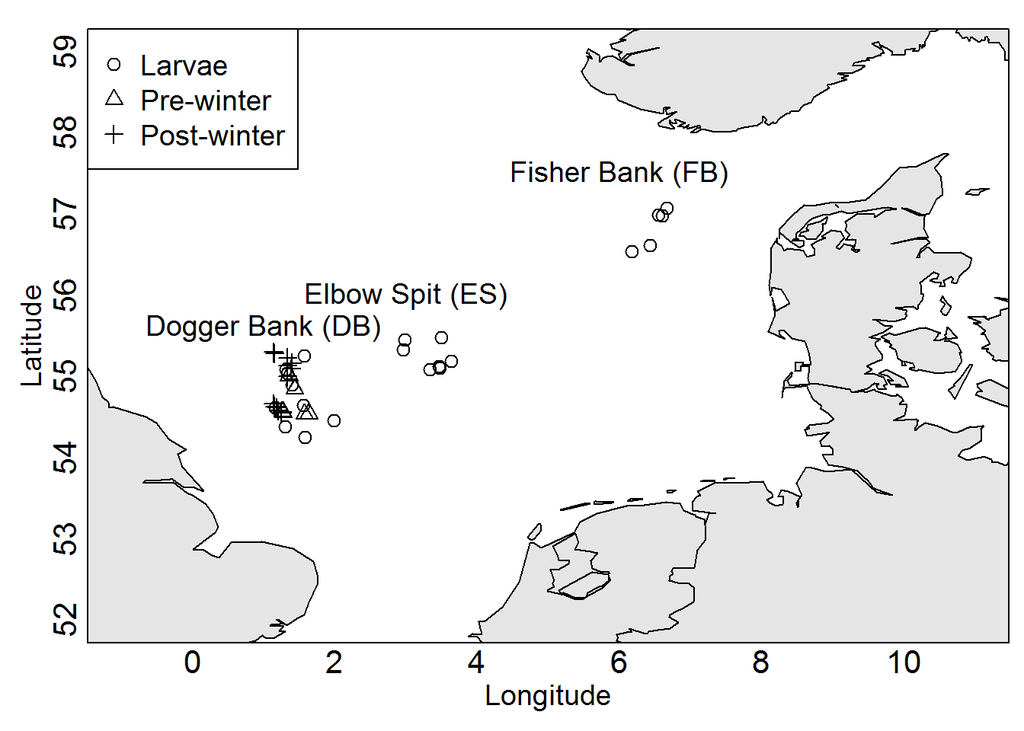

# 6 Larvae otoliths

# 7 Larvae length and age relation

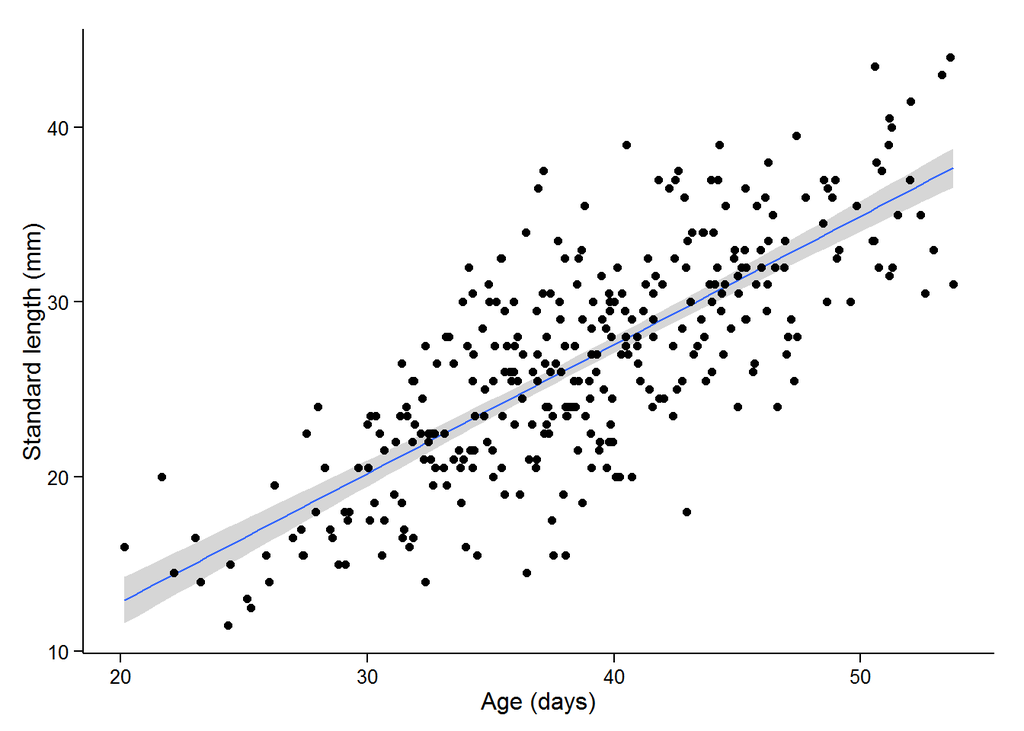

```r
library(ggplot2)
ggplot(d,aes(age,sd_lgd))+
  geom_smooth(method=lm)+
  geom_point()+
  ylab("Standard length (mm)")+
  xlab("Age (days)")+
  theme_classic()
```

### 7.0.1 lm length at age

```r
lm(data=d,sd_lgd~age)
```

```
##
## Call:
## lm(formula = sd_lgd ~ age, data = d)
##
## Coefficients:
## (Intercept)          age
##     -1.8990       0.7364
```

## 7.1 Fish otoliths

Without traeatment

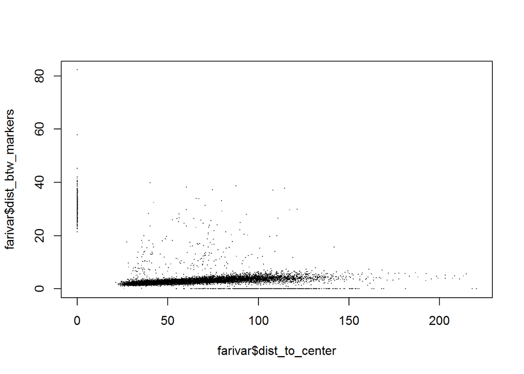

```r
library(ggplot2)
plot(farivar$dist_to_center,farivar$dist_btw_markers,pch=".")
```

and with treatment

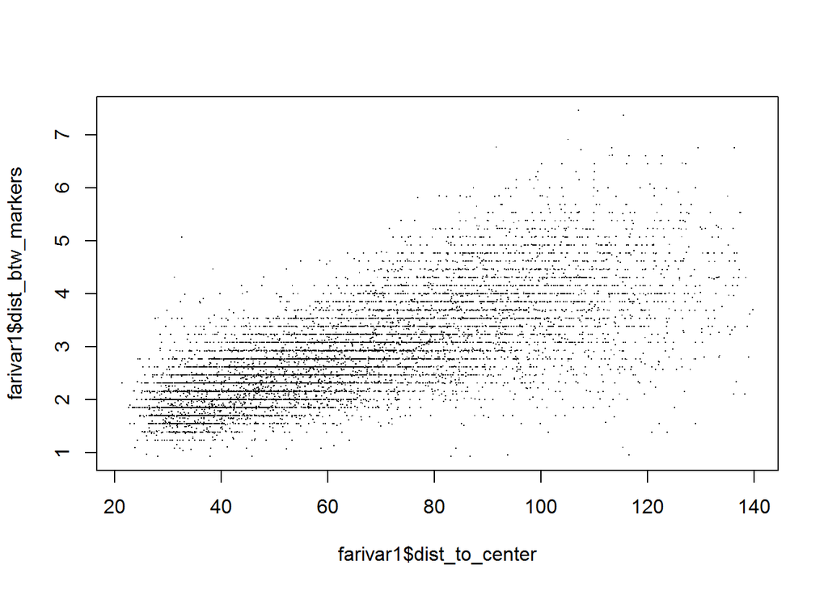

```r
plot(farivar1$dist_to_center,farivar1$dist_btw_markers,pch=".")
```

## 7.2 Fish lenght and growth estimates

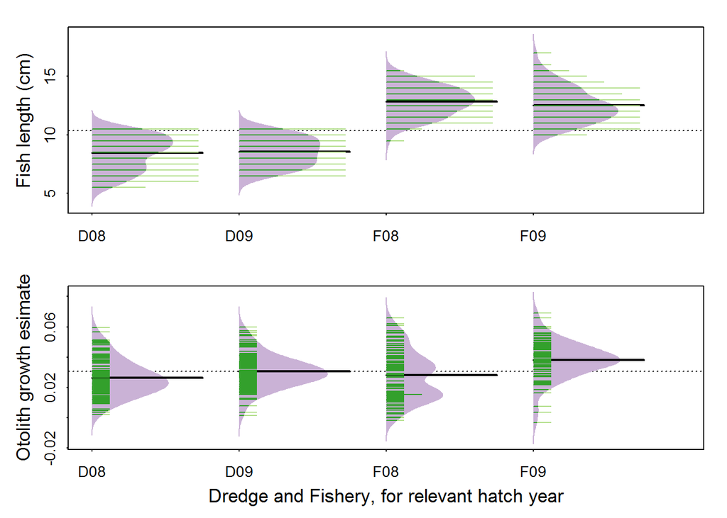

```r
library(beanplot)
par(mfrow=c(2,1),cex=1.1,mar=c(2,3,1.2,1),tck=-0.01,mgp = c(3, 0.4, 0),cex.main=0.8,cex.axis=0.8,cex.lab=0.9)

beanplot(fish_length~FDyear,data=farplotting2,what=c(1,1,1,1),boxwex = 1.5,log="",side="second",col = c("#CAB2D6", "#33A02C", "#B2DF8A"), border = "#CAB2D6")
 mtext("Fish length (cm)", side=2, line=1.5,cex=1.1)

par(mar=c(3,3,1.2,1))
beanplot(slope_estimate~FDyear,data=farplotting2,what=c(1,1,1,1),boxwex = 1.5,log="",side="second",col = c("#CAB2D6", "#33A02C", "#B2DF8A"), border = "#CAB2D6")
mtext("Otolith growth esimate", side=2, line=1.5,cex=1.1)
mtext("Dredge and Fishery, for relevant hatch year", side=1, line=1.5,cex=1.1)
```

### 7.2.1 Density plots of fish otolith growth pr station

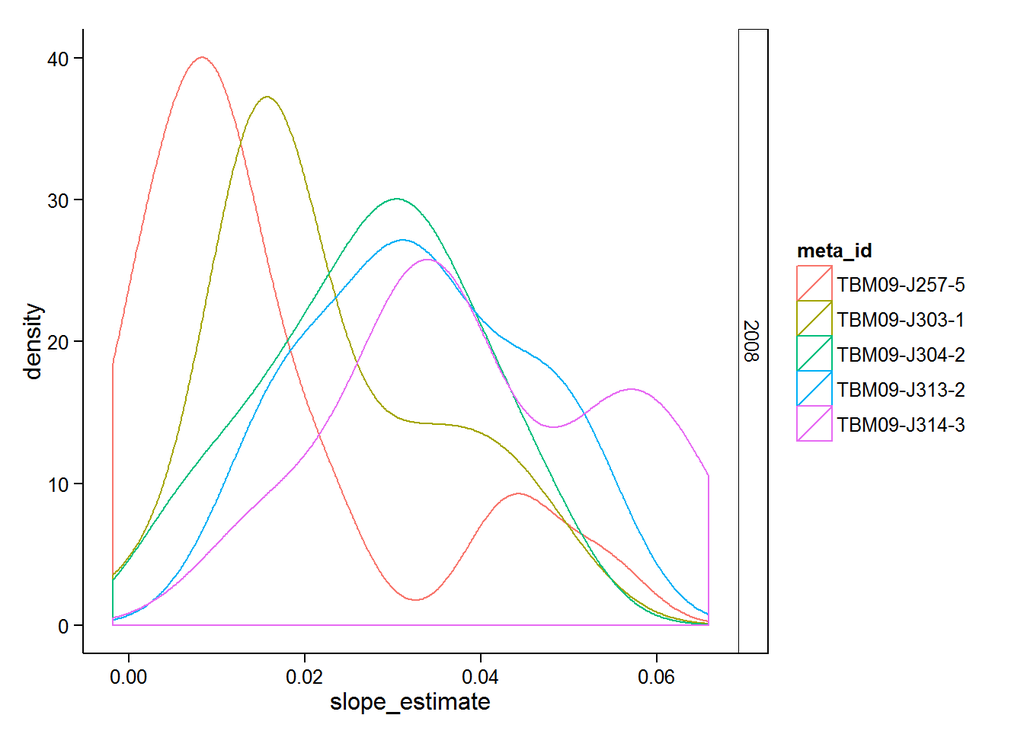

```r
library(ggplot2)
ggplot(filter(farivar2,hatch_year==2008,fishery_dredge=="Fishery"),aes(slope_estimate,colour=meta_id))+theme_classic()+geom_density()+facet_grid(hatch_year~.)
```

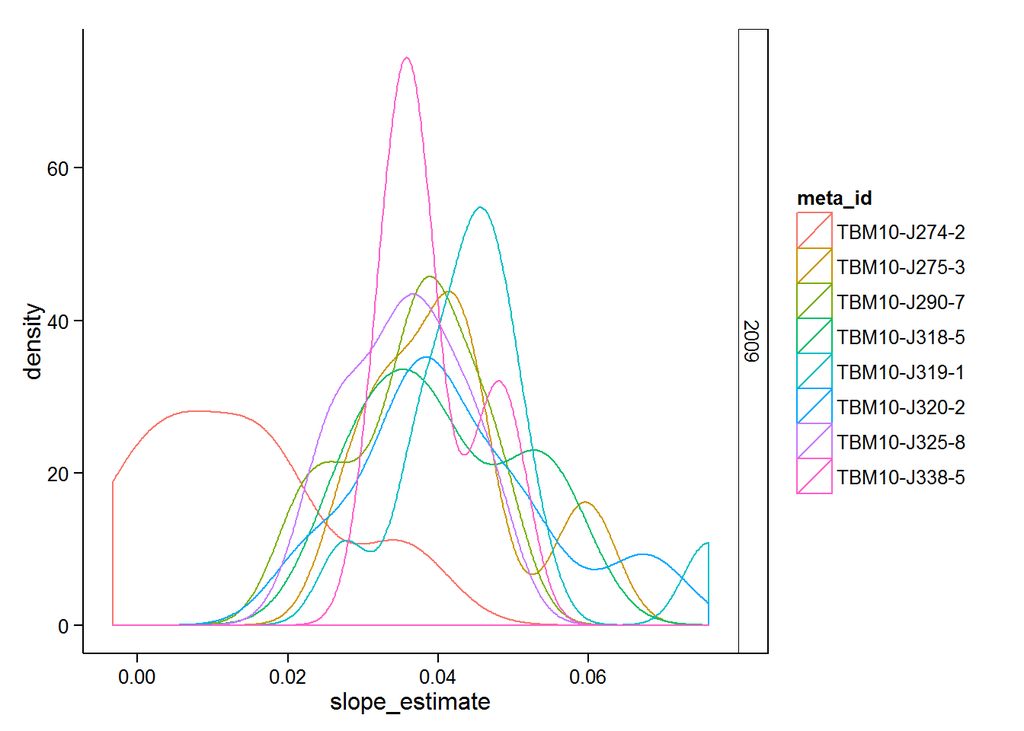

```r
ggplot(filter(farivar2,fishery_dredge=="Fishery",hatch_year==2009),aes(slope_estimate,colour=meta_id))+theme_classic()+geom_density()+facet_grid(hatch_year~.)
```

## 7.3 Fish & larvae same plot

Both fish and larvae in same plots

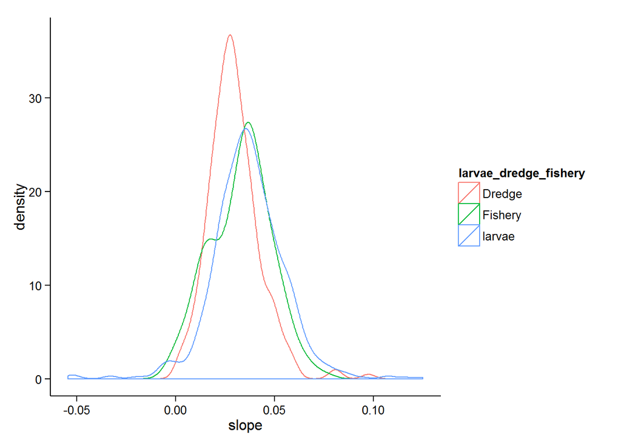

```r
library(ggplot2)

larvae_slopes <- oto5%>%
  mutate(larvae_dredge_fishery = "larvae",
         hatch_year = factor(year))%>%
  select(slope,hatch_year,area,larvae_dredge_fishery,growth_center)


fish_slopes<- farivar2%>%
  mutate(larvae_dredge_fishery = fishery_dredge,
         slope=slope_estimate,
         area="DB",
         growth_center="NA",
         hatch_year=factor(hatch_year))%>%
  select(slope,hatch_year,area,larvae_dredge_fishery,growth_center)

larvae_and_fish <- rbind(fish_slopes,larvae_slopes)

#dentity plot
ggplot(larvae_and_fish,aes(slope,colour=larvae_dredge_fishery))+theme_classic()+geom_density()
```

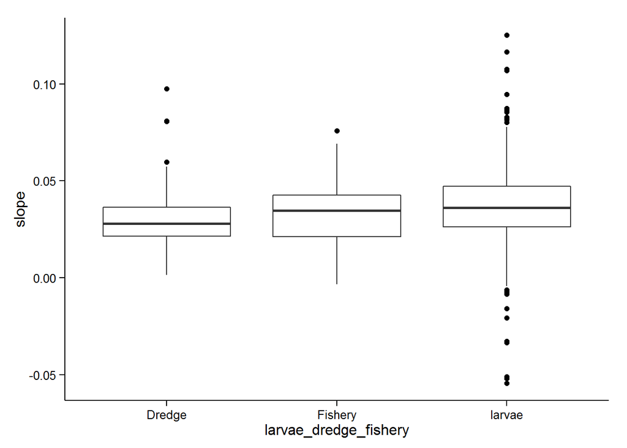

```r
#And with a boxplot

ggplot(larvae_and_fish,aes(y=slope,x=larvae_dredge_fishery))+theme_classic()+geom_boxplot()
```

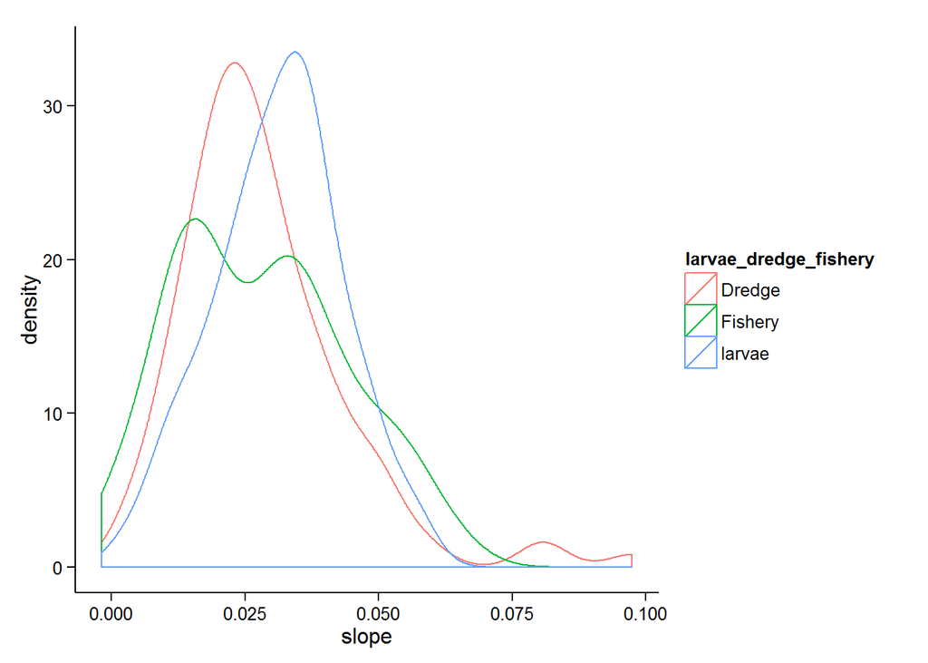

```r
#And only for Dogger and 2008

ggplot(filter(larvae_and_fish,hatch_year=="2008",area=="DB"),aes(slope,colour=larvae_dredge_fishery))+theme_classic()+geom_density()
```

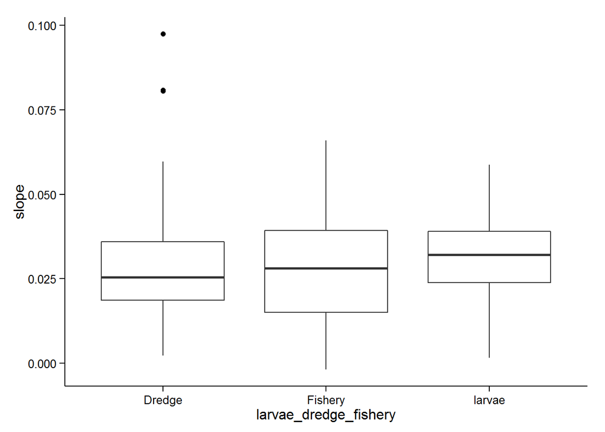

```r
ggplot(filter(larvae_and_fish,hatch_year=="2008",area=="DB"),aes(y=slope,x=larvae_dredge_fishery))+theme_classic()+geom_boxplot()
```

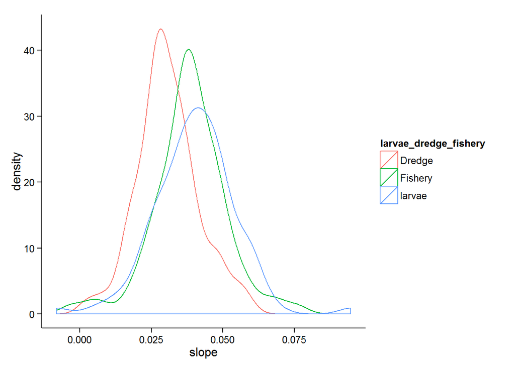

```r
#Dogger 2009

ggplot(filter(larvae_and_fish,hatch_year=="2009",area=="DB"),aes(slope,colour=larvae_dredge_fishery))+theme_classic()+geom_density()
```

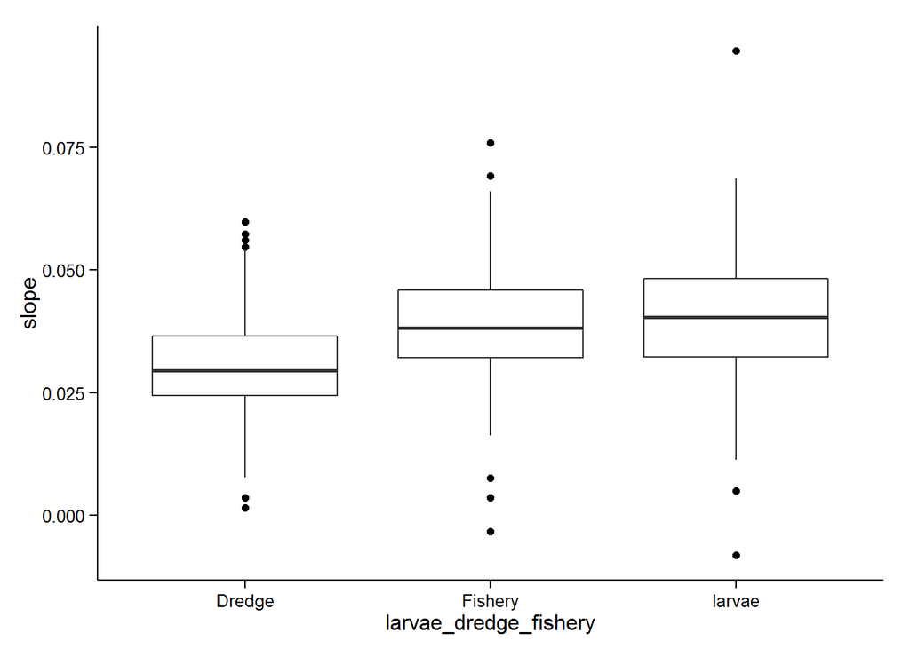

```r
ggplot(filter(larvae_and_fish,hatch_year=="2009",area=="DB"),aes(y=slope,x=larvae_dredge_fishery))+theme_classic()+geom_boxplot()
```

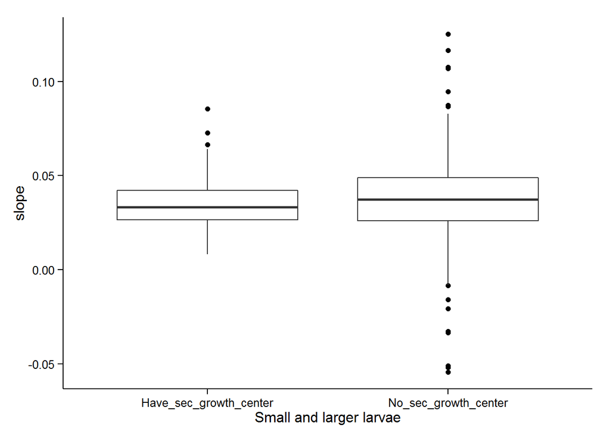

```r
ggplot(filter(larvae_and_fish,larvae_dredge_fishery=="larvae"),aes(y=slope,x=growth_center))+theme_classic()+geom_boxplot()+xlab("Small and larger larvae")
```

# 8 Models and statistics

## 8.1 Length~width*dist_to_center ### lm models I devide the larve into large and small by selecting on whether otolith have secondary growth center or not.

```r
m1a.lm<-lm(sd_lgd~dist_btw_markers*dist_to_center,data=filter(oto4,growth_center=="No_sec_growth_center"))
summary(m1a.lm)
```

```
##
## Call:
## lm(formula = sd_lgd ~ dist_btw_markers * dist_to_center, data = filter(oto4,
##     growth_center == "No_sec_growth_center"))
##
## Residuals:
##      Min       1Q   Median       3Q      Max
## -15.5530  -2.9211   0.0274   2.9912  13.6813
##
## Coefficients:
##                                  Estimate Std. Error t value Pr(>|t|)
## (Intercept)                     15.650226   0.331093  47.268   <2e-16 ***
## dist_btw_markers                 2.683570   0.174574  15.372   <2e-16 ***
## dist_to_center                   0.129297   0.007790  16.597   <2e-16 ***
## dist_btw_markers:dist_to_center -0.024022   0.002798  -8.586   <2e-16 ***
## ---
## Signif. codes:  0 '***' 0.001 '**' 0.01 '*' 0.05 '.' 0.1 ' ' 1
##
## Residual standard error: 4.212 on 9155 degrees of freedom
##   (214 observations deleted due to missingness)
## Multiple R-squared:  0.2182, Adjusted R-squared:  0.2179
## F-statistic: 851.6 on 3 and 9155 DF,  p-value: < 2.2e-16
```

```r
m2a.lm<-lm(sd_lgd~dist_btw_markers*dist_to_center,data=filter(oto4,growth_center=="Have_sec_growth_center"))
summary(m2a.lm)
```

```
##
## Call:
## lm(formula = sd_lgd ~ dist_btw_markers * dist_to_center, data = filter(oto4,
##     growth_center == "Have_sec_growth_center"))
##
## Residuals:
##     Min      1Q  Median      3Q     Max
## -9.5136 -2.6612 -0.6599  2.3248 10.5024
##
## Coefficients:
##                                  Estimate Std. Error t value Pr(>|t|)
## (Intercept)                     33.992337   0.429218  79.196  < 2e-16 ***
## dist_btw_markers                -0.565218   0.186189  -3.036  0.00241 **
## dist_to_center                   0.007934   0.006640   1.195  0.23225
## dist_btw_markers:dist_to_center  0.006638   0.002130   3.117  0.00184 **
## ---
## Signif. codes:  0 '***' 0.001 '**' 0.01 '*' 0.05 '.' 0.1 ' ' 1
##
## Residual standard error: 3.686 on 4543 degrees of freedom
## Multiple R-squared:  0.02492,    Adjusted R-squared:  0.02427
## F-statistic: 38.69 on 3 and 4543 DF,  p-value: < 2.2e-16
```

Another option is to devide larvae sizes from a mean or median length:

```r
#the mean larvae length
mean_larvae_length <- mean(rbind(l_06,rbind(l_08,l_09))$sd_lgd)

#apply to data frames
oto5 <- oto5 %>%
  mutate(small_large=ifelse(sd_lgd<=mean_larvae_length,"small","large"))

oto4 <- oto4%>%
  left_join(.,select(oto5,small_large,pic_id),by="pic_id")

#new models
m1b.lm<-lm(sd_lgd~dist_btw_markers*dist_to_center,data=filter(oto4,small_large=="small"))
summary(m1b.lm)
```

```
##
## Call:
## lm(formula = sd_lgd ~ dist_btw_markers * dist_to_center, data = filter(oto4,
##     small_large == "small"))
##
## Residuals:
##      Min       1Q   Median       3Q      Max
## -12.1699  -2.2666   0.3104   2.4118   7.7946
##
## Coefficients:
##                                  Estimate Std. Error t value Pr(>|t|)
## (Intercept)                     14.845023   0.305523  48.589   <2e-16 ***
## dist_btw_markers                 2.500160   0.162292  15.405   <2e-16 ***
## dist_to_center                   0.115544   0.007997  14.449   <2e-16 ***
## dist_btw_markers:dist_to_center -0.026845   0.003242  -8.282   <2e-16 ***
## ---
## Signif. codes:  0 '***' 0.001 '**' 0.01 '*' 0.05 '.' 0.1 ' ' 1
##
## Residual standard error: 3.303 on 9824 degrees of freedom
## Multiple R-squared:  0.1856, Adjusted R-squared:  0.1853
## F-statistic: 746.1 on 3 and 9824 DF,  p-value: < 2.2e-16
```

```r
m2b.lm<-lm(sd_lgd~dist_btw_markers*dist_to_center,data=filter(oto4,small_large=="large"))
summary(m2b.lm)
```

```
##
## Call:
## lm(formula = sd_lgd ~ dist_btw_markers * dist_to_center, data = filter(oto4,
##     small_large == "large"))
##
## Residuals:
##     Min      1Q  Median      3Q     Max
## -7.1483 -2.7880 -0.7959  1.8916 12.9031
##
## Coefficients:
##                                  Estimate Std. Error t value Pr(>|t|)
## (Intercept)                     31.446626   0.280063 112.284  < 2e-16 ***
## dist_btw_markers                -0.830330   0.125474  -6.618 3.84e-11 ***
## dist_to_center                   0.029425   0.004822   6.102 1.09e-09 ***
## dist_btw_markers:dist_to_center  0.008089   0.001537   5.264 1.44e-07 ***
## ---
## Signif. codes:  0 '***' 0.001 '**' 0.01 '*' 0.05 '.' 0.1 ' ' 1
##
## Residual standard error: 3.687 on 9828 degrees of freedom
## Multiple R-squared:  0.06144,    Adjusted R-squared:  0.06116
## F-statistic: 214.5 on 3 and 9828 DF,  p-value: < 2.2e-16
```

### 8.1.1 lm width~dist_center*size

```r
#Reviewing distance to center measures, I add 4 wich would be around 2 to 4 rings in this area

distance_limit <- min(oto4$radius_1_length)+4

#Modelling increment width as function of distance to center and catagorigal size
m1c.lm <- lm(dist_btw_markers~dist_to_center*factor(small_large),data=filter(oto4,dist_to_center<distance_limit))
summary(m1c.lm)
```

```
##
## Call:
## lm(formula = dist_btw_markers ~ dist_to_center * factor(small_large),
##     data = filter(oto4, dist_to_center < distance_limit))
##
## Residuals:
##      Min       1Q   Median       3Q      Max
## -0.78625 -0.25197 -0.05018  0.18086  2.23187
##
## Coefficients:
##                                          Estimate Std. Error t value
## (Intercept)                              0.883937   0.102380   8.634
## dist_to_center                           0.024088   0.003744   6.433
## factor(small_large)small                -0.040831   0.112176  -0.364
## dist_to_center:factor(small_large)small -0.003587   0.004126  -0.869
##                                         Pr(>|t|)
## (Intercept)                              < 2e-16 ***
## dist_to_center                          1.42e-10 ***
## factor(small_large)small                   0.716
## dist_to_center:factor(small_large)small    0.385
## ---
## Signif. codes:  0 '***' 0.001 '**' 0.01 '*' 0.05 '.' 0.1 ' ' 1
##
## Residual standard error: 0.3626 on 3531 degrees of freedom
##   (50 observations deleted due to missingness)
## Multiple R-squared:  0.08001,    Adjusted R-squared:  0.07923
## F-statistic: 102.4 on 3 and 3531 DF,  p-value: < 2.2e-16
```

```r
#Modelling increment width as function of distance to center and continous size
m2c.lm<-lm(dist_btw_markers~dist_to_center*sd_lgd,data=filter(oto4,dist_to_center<distance_limit))
summary(m2c.lm)
```

```
##
## Call:
## lm(formula = dist_btw_markers ~ dist_to_center * sd_lgd, data = filter(oto4,
##     dist_to_center < distance_limit))
##
## Residuals:
##      Min       1Q   Median       3Q      Max
## -0.83814 -0.24546 -0.04877  0.17987  2.23069
##
## Coefficients:
##                         Estimate Std. Error t value Pr(>|t|)
## (Intercept)            5.238e-01  1.586e-01   3.303 0.000966 ***
## dist_to_center         2.119e-02  5.982e-03   3.542 0.000402 ***
## sd_lgd                 1.696e-02  7.109e-03   2.386 0.017105 *
## dist_to_center:sd_lgd -9.212e-05  2.653e-04  -0.347 0.728394
## ---
## Signif. codes:  0 '***' 0.001 '**' 0.01 '*' 0.05 '.' 0.1 ' ' 1
##
## Residual standard error: 0.3567 on 3531 degrees of freedom
##   (50 observations deleted due to missingness)
## Multiple R-squared:  0.1094, Adjusted R-squared:  0.1086
## F-statistic: 144.6 on 3 and 3531 DF,  p-value: < 2.2e-16
```